# Data Explorations

# Trials, Errors and Lessons

```r
usm_schools <- c(
  "Bowie State University",
  "Coppin State University",
  "Frostburg State University",
  "Salisbury University",
  "Towson University",
  "University of Maryland Eastern Shore",
  "University of Maryland, Baltimore",
  "University of Maryland-Baltimore County",
  "University of Maryland-College Park"
)

# Explicit IDs avoid depending on inconsistent campus names such as
# "Main Campus", "Towson University", and "Coppin State University".
primary_campus_ids <- c(
  "162007001", "162283001", "162584001", "163851001", "164076001",
  "163338001", "163259001", "163268001", "163286001"
)

campus_crime <- read_csv(
  "https://raw.githubusercontent.com/dwillis/jour405/refs/heads/main/data/usm_oncampus_crime_2015_2024.csv",
  col_types = cols(
    campus_id = col_character(),
    ope_id = col_character(),
    zip = col_character(),
    us_scope = col_character(),
    older_than_latest_collection = col_character()
  ),
  show_col_types = FALSE
)

USMCrime <- campus_crime |>
  filter(institution_name %in% usm_schools) |>
  mutate(is_primary_campus = campus_id %in% primary_campus_ids) |>
  arrange(institution_name, campus_id, crime_year)

USMCrime_primary <- USMCrime |>
  filter(is_primary_campus)
```

In the block above, I filtered the USM schools (excluding University of Baltimore, UMGC and the University of Maryland Center for Environmental Science) down to their main campuses. The schools are called by their IDs to avoid confusion (e.g., if University of Maryland, Baltimore happens to be confused with UMBC). I also loaded crime data from 2015-2014. This was just a preliminary block to get all the data sorted.

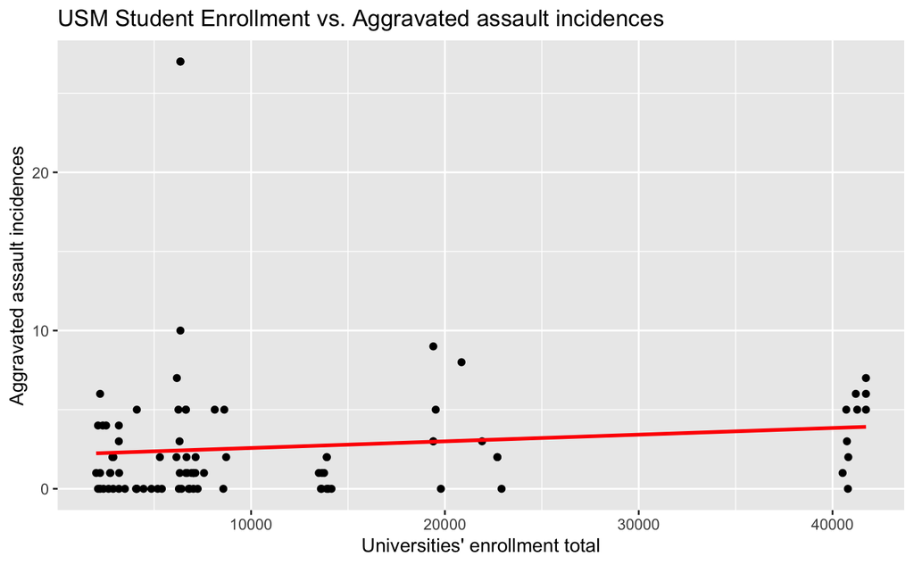

```r
USMCrime_primary |>
  ggplot(aes(x = `source_enrollment_total`, y = `AGG_A`)) +
  geom_point() +
  geom_smooth(method = "lm", se = FALSE, color = "red") +
  labs(x = "Universities' enrollment total", y = "Aggravated assault incidences",
       title = "USM Student Enrollment vs. Aggravated assault incidences")
```

The issue with graph is that it doesn’t label the different schools or years. A multiple linear regression graph would suit the data set better, but I’ll wait until we go through an in-class example for that before I put it to the test.

Without the labels for schools and years, it’s hard to visually determine which schools are driving the data to the right. It’s also difficult to compare aggravated assault incidents this way because nothing is clearly labeled.

The data is also hard to read because the graph doesn’t calculate crime rates per 1,000 enrolled students. I also can’t show the other violent crime categories (murder, rape, etc.) without a multiple linear regression line. How would I go about including that data into a graph for future tests?

# Tests I could run

I think a bar chart would be effective in visualizing violent crime rates across USM campuses. The X-axis could contain the school names, whereas the X-axis shows violent crime rates (I’ll have to look at the years of data I have to determine the maximum threshold). I could do year comparisons to analyze if the rates have changed– maybe comparing a bar chart with 2015 data to a chart with 2024 data.

My refined hypothesis is: “Across Maryland’s four-year public and private nonprofit colleges, is the percentage of students living on campus associated with reported violent crime rates?” I could use percentages instead of rates for these bar charts. The X-axis, in this case, could show the number of students living on campus, but I’m not sure how to incorporate that.

I also want to use confidence interval models. There’s an unknown number of violent crimes that may go unreported for unknown reasons. Including confidence intervals would acknowledge that the data provided in this link (https://raw.githubusercontent.com/dwillis/jour405/refs/heads/main/data/oncampus_crime_campus_year.csv) could not be entirely accurate. To do this, though, would I make confidence interval models for each school? Is there a better way to portray this in one model?

I could also do a linear regression model to see if there’s a correlation between percentage of students living on campus and violent crime rates. This would help me visualize if there is any correlation– and if there is– how strong or weak it is.

I was wondering if a t-test would be appropriate and how I could conduct that across all the schools. Based on the results, I could interpret whether or not the null hypothesis, but if we do fail to reject the null hypothesis, what would that null hypothesis be? Saying “there is no change” doesn’t seem to fit.

# Source 1: U.S. Department of Education, Campus Safety and Security (https://ope.ed.gov/campussafety/#/)

```r
USMCrime <- read_csv("Criminal_Offenses_On_campus.csv")
```

The data comes from the U.S. Department of Education’s Campus Safety and Security Data Analysis Cutting Tool, which allows users to download campus crime and fire data. For this project, I downloaded data from 2015-2024 from all University System of Maryland schools, excluding University of Baltimore (primarily graduate and professional students), University of Maryland, Global Campus (mainly online and does not have a main campus) and Center for Environmental Science (a research center).

The Department of Education pulls this data from the OPE Campus Safety and Security Statistics website database, where the USM reports their crime and fire statistics annually.

I collected the data using the ‘Download Custom Data’ tool. I selected the schools I will analyze, made the time frame 2015-2024 (2025 data is not available online yet), chose ‘Con-campus’ for the location and narrowed the crime category down to ‘Criminal Offenses - On campus.’ The data contains the school names, institution sizes, the survey years and crime categories. The crime categories are Murder/Non-negligent manslaughter, Negligent manslaughter, Sex offenses - Forcible, Rape, Fondling, Sex Offenses - Non-forcible, Incest, Statutory rape, Robbery, Aggravated assault, Burglary, Motor vehicle theft and Arson.

The columns most important to my analysis are Murder, both Sex offenses, Robbery and Aggravated assault. These will help me analyze violent crimes across multiple situations and environments. The incident counts for these are there, but I will have to turn these into rates– should I calculate the rates by the institution size provided in the data to get incidents per 1,000 students? Since I’m looking at on-campus incidents, I may need help finding the on-campus student numbers if I run into trouble with that.

The data is in the project file.